# Exploratory Data Analysis On Top 5000 YouTube Channels

### [ This code is developed by KRUSHNA PRASAD SAHOO ]

In this project , I have performed EDA on a data set which contains 5000 rows of data and 6 columns namely Rank , Grade , Channel Name , Video Uploads , Subscribers , Video Views . I have analyzed and visualized it and possibly formulated some hypotheses that may lead to new data collection and experiments further .

### 1 . Import necessary Libraries

```python
import os
import numpy as np
import pandas as pd
import matplotlib.pyplot as plt
import seaborn as sns
```

### 2 . Fetch the Data set

```python
data_youtube = pd.read_csv('Top_5000_Youtube_Channels_Data_CSV.csv')
```

### 3 . Start Exploring

```python
# let us have a look into first few rows of our data set
data_youtube.head(20)
```

|  | Rank | Grade | Channel name | Video Uploads | Subscribers | Video views |
| --- | --- | --- | --- | --- | --- | --- |
| 0 | 1st | A++ | Zee TV | 82757 | 18752951 | 20869786591 |
| 1 | 2nd | A++ | T-Series | 12661 | 61196302 | 47548839843 |
| 2 | 3rd | A++ | Cocomelon - Nursery Rhymes | 373 | 19238251 | 9793305082 |
| 3 | 4th | A++ | SET India | 27323 | 31180559 | 22675948293 |
| 4 | 5th | A++ | WWE | 36756 | 32852346 | 26273668433 |
| 5 | 6th | A++ | Movieclips | 30243 | 17149705 | 16618094724 |
| 6 | 7th | A++ | netd müzik | 8500 | 11373567 | 23898730764 |
| 7 | 8th | A++ | ABS-CBN Entertainment | 100147 | 12149206 | 17202609850 |
| 8 | 9th | A++ | Ryan ToysReview | 1140 | 16082927 | 24518098041 |
| 9 | 10th | A++ | Zee Marathi | 74607 | 2841811 | 2591830307 |
| 10 | 11th | A+ | 5-Minute Crafts | 2085 | 33492951 | 8587520379 |
| 11 | 12th | A+ | Canal KondZilla | 822 | 39409726 | 19291034467 |
| 12 | 13th | A+ | Like Nastya Vlog | 150 | 7662886 | 2540099931 |
| 13 | 14th | A+ | Ozuna | 50 | 18824912 | 8727783225 |
| 14 | 15th | A+ | Wave Music | 16119 | 15899764 | 10989179147 |
| 15 | 16th | A+ | Ch3Thailand | 49239 | 11569723 | 9388600275 |
| 16 | 17th | A+ | WORLDSTARHIPHOP | 4778 | 15830098 | 11102158475 |
| 17 | 18th | A+ | Vlad and Nikita | 53 | -- | 1428274554 |
| 18 | 19th | A+ | Badabun | 3060 | 23603062 | 5860444053 |
| 19 | 20th | A+ | WorkpointOfficial | 24287 | 17687229 | 14022189654 |

```python
# let's get the rows and columns of the data set
print(data_youtube.shape )

# let's get more mathematical details about it
data_youtube.describe()
```

```
(5000, 6)
```

|  | Video views |
| --- | --- |
| count | 5.000000e+03 |
| mean | 1.071449e+09 |
| std | 2.003844e+09 |
| min | 7.500000e+01 |
| 25% | 1.862329e+08 |
| 50% | 4.820548e+08 |
| 75% | 1.124368e+09 |
| max | 4.754884e+10 |

```python
# let us get basic info about our data set
data_youtube.info()
```

```
<class 'pandas.core.frame.DataFrame'>
RangeIndex: 5000 entries, 0 to 4999
Data columns (total 6 columns):
 #   Column         Non-Null Count  Dtype
---  ------         --------------  -----
 0   Rank           5000 non-null   object
 1   Grade          5000 non-null   object
 2   Channel name   5000 non-null   object
 3   Video Uploads  5000 non-null   object
 4   Subscribers    5000 non-null   object
 5   Video views    5000 non-null   int64
dtypes: int64(1), object(5)
memory usage: 234.5+ KB
```

##### We can observe clearly that all values are object data type except " Video views " .

```python
# let's check the frequency of values in descending order
data_youtube['Subscribers'].value_counts()


# now '--' has the max frequency of 387 times
# missing value.
```

```
--         387
666561       2
92158        2
3087993      1
410252       1
          ...
7877716      1
3159258      1
1335725      1
1243105      1
655701       1
Name: Subscribers, Length: 4612, dtype: int64
```

##### Here we can see that the missing value i.e " -- " has the maximum frequency of 387 times .

### 4 . Missing Value Treatment

```python
# Let's create a new dataframe which will not contain the missing values
missing_values = data_youtube['Subscribers'].value_counts().index[0]
data_yt_1 = data_youtube[data_youtube['Subscribers'] != missing_values]
data_yt_1.info()
```

```
<class 'pandas.core.frame.DataFrame'>
Int64Index: 4613 entries, 0 to 4999
Data columns (total 6 columns):
 #   Column         Non-Null Count  Dtype
---  ------         --------------  -----
 0   Rank           4613 non-null   object
 1   Grade          4613 non-null   object
 2   Channel name   4613 non-null   object
 3   Video Uploads  4613 non-null   object
 4   Subscribers    4613 non-null   object
 5   Video views    4613 non-null   int64
dtypes: int64(1), object(5)
memory usage: 252.3+ KB
```

#### Now missing values are suceesssfully removed . Total remaing rows are 4613 now .

### 5 . Conversion of Object Datatype to Integer

```python
# Now, lets convert the Subscribers data to intergers.
data_yt_1['Subscribers'] = pd.to_numeric(data_yt_1['Subscribers'])
data_yt_1.describe()
```

|  | Subscribers | Video views |
| --- | --- | --- |
| count | 4.613000e+03 | 4.613000e+03 |
| mean | 2.620004e+06 | 1.137713e+09 |
| std | 3.926447e+06 | 2.068211e+09 |
| min | 3.010000e+02 | 7.500000e+01 |
| 25% | 6.098940e+05 | 2.188379e+08 |
| 50% | 1.350477e+06 | 5.365047e+08 |
| 75% | 2.950056e+06 | 1.194442e+09 |
| max | 6.599531e+07 | 4.754884e+10 |

```python
# let's check the frequency of values in descending order
data_yt_1['Subscribers'].value_counts()
```

```
666561     2
92158      2
328377     1
2413227    1
2908845    1
          ..
864657     1
2358605    1
1316176    1
3693905    1
2254849    1
Name: Subscribers, Length: 4611, dtype: int64
```

```python
# The following line replaces the missing value with NaN and it drops the row.
data_final = data_yt_1.replace('--', np.nan).dropna()
```

#### Removal of missing values and coversion from Object to Integer datatype is now done successfully for " Subscribers " .

```python
# This fuctions converts the object value to interger value.
data_final['Video Uploads'] = pd.to_numeric(data_final['Video Uploads'])
```

```python
data_final.describe()
```

|  | Video Uploads | Subscribers | Video views |
| --- | --- | --- | --- |
| count | 4610.000000 | 4.610000e+03 | 4.610000e+03 |
| mean | 4085.745987 | 2.621527e+06 | 1.138403e+09 |
| std | 17726.160260 | 3.927263e+06 | 2.068706e+09 |
| min | 1.000000 | 3.010000e+02 | 7.500000e+01 |
| 25% | 148.000000 | 6.101925e+05 | 2.189184e+08 |
| 50% | 464.000000 | 1.350884e+06 | 5.368886e+08 |
| 75% | 1592.500000 | 2.950921e+06 | 1.195115e+09 |
| max | 422326.000000 | 6.599531e+07 | 4.754884e+10 |

```python
data_final.info()
```

```
<class 'pandas.core.frame.DataFrame'>
Int64Index: 4610 entries, 0 to 4999
Data columns (total 6 columns):
 #   Column         Non-Null Count  Dtype
---  ------         --------------  -----
 0   Rank           4610 non-null   object
 1   Grade          4610 non-null   object
 2   Channel name   4610 non-null   object
 3   Video Uploads  4610 non-null   int64
 4   Subscribers    4610 non-null   int64
 5   Video views    4610 non-null   int64
dtypes: int64(3), object(3)
memory usage: 252.1+ KB
```

#### At this point the dataset contains no missing values & the last three columns are of integer datatype. So we are good to proceed.

### 6 . Detect and remove Outliers

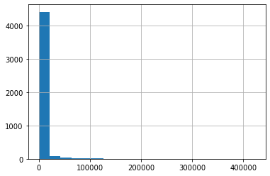

```python
# Let's plot the histogram of the comlumn named " Video Uploads "
data_final['Video Uploads'].hist(bins=20)
```

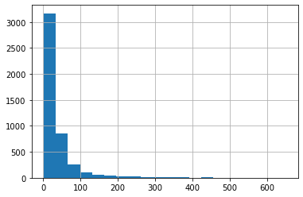

```python
# Calculating sqrt and plotting .
data_final_vu_sqrt = np.sqrt(data_final['Video Uploads'])
data_final_vu_sqrt.hist(bins=20)
```

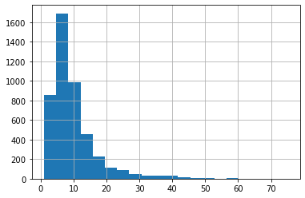

```python
# Calculating cbrt and plotting .
data_final_vu_cbrt = np.cbrt(data_final['Video Uploads'])
data_final_vu_cbrt.hist(bins=20)
```

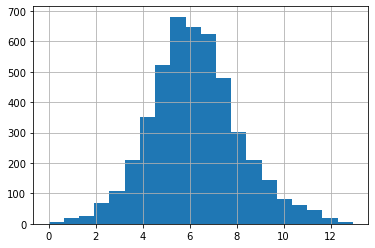

```python
# Calculating the log & plotting it .
data_final_vu_log = np.log(data_final['Video Uploads'])
data_final_vu_log.hist(bins=20)
```

#### Now let's do the same for next column i.e " Subscribers "

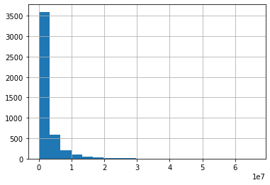

```python
# Let's plot its histogram .
data_final['Subscribers'].hist(bins=20)
```

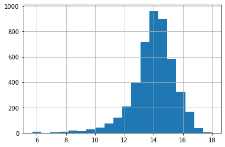

```python
# log.
data_final_s_log = np.log(data_final['Subscribers'])
data_final_s_log.hist(bins=20)
```

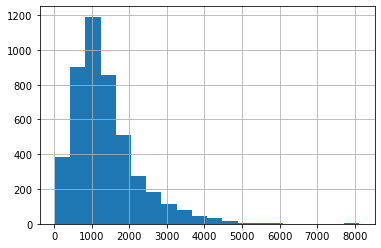

```python
# sqrt .
data_final_s_sqrt = np.sqrt(data_final['Subscribers'])
data_final_s_sqrt.hist(bins=20)
```

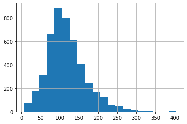

```python
# cbrt
data_final_s_cbrt = np.cbrt(data_final['Subscribers'])
data_final_s_cbrt.hist(bins=20)
```

#### We can see that the above graph is less skewed as compared to the others .

#### Now let's do the same for another column i.e " Video views "

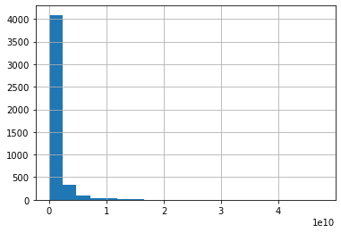

```python
# plot the histogram
data_final['Video views'].hist(bins=20)
```

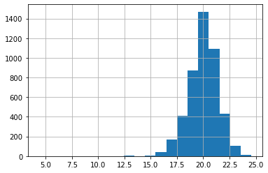

```python
# log.
data_final_vv_log = np.log(data_final['Video views'])
data_final_vv_log.hist(bins=20)
```

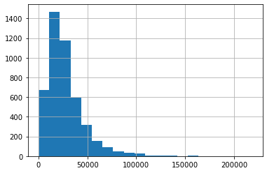

```python
# Sqrt .
data_final_vv_sqrt = np.sqrt(data_final['Video views'])
data_final_vv_sqrt.hist(bins=20)
```

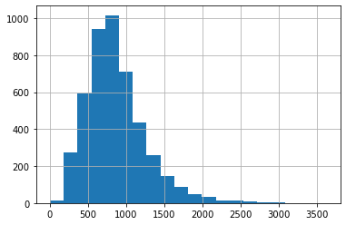

```python
# Cbrt .
data_final_vv_cbrt = np.cbrt(data_final['Video views'])
data_final_vv_cbrt.hist(bins=20)
```

#### We can observe the log is giving less skewed than others .

#### let's check the histograms at once for those three columns

```
array([[<matplotlib.axes._subplots.AxesSubplot object at 0x0000012F868A6FC8>,
      dtype=object)
```

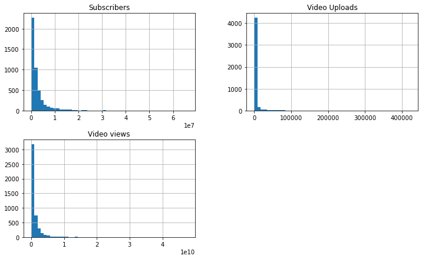

```python
from matplotlib import pyplot as plt
fig, ax = plt.subplots(figsize = (12, 7))
data_final.hist(bins = 50, ax = ax)
```

### The above distribution shows that :

[output not shown]

### 7 . Find Top 50

#### Let's see the top 50 subscribed YouTube channels according to the dataset .

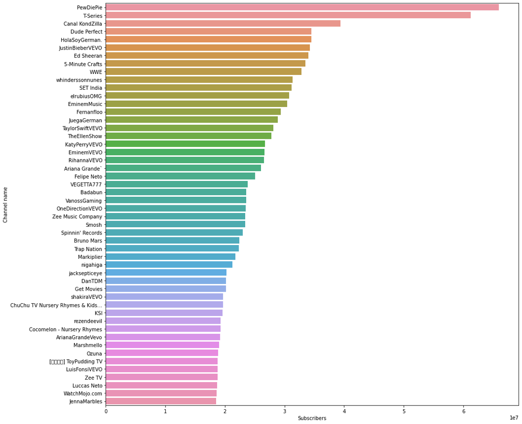

```python
import seaborn as sns
df_subs_and_channels_top_50 = data_final[['Channel name', 'Subscribers']].sort_values('Subscribers', ascending = False)[:50]
fig, ax = plt.subplots(figsize = (15, 15))
sns.barplot(y = 'Channel name', x = 'Subscribers', data = df_subs_and_channels_top_50, orient = 'h',ax = ax)
```

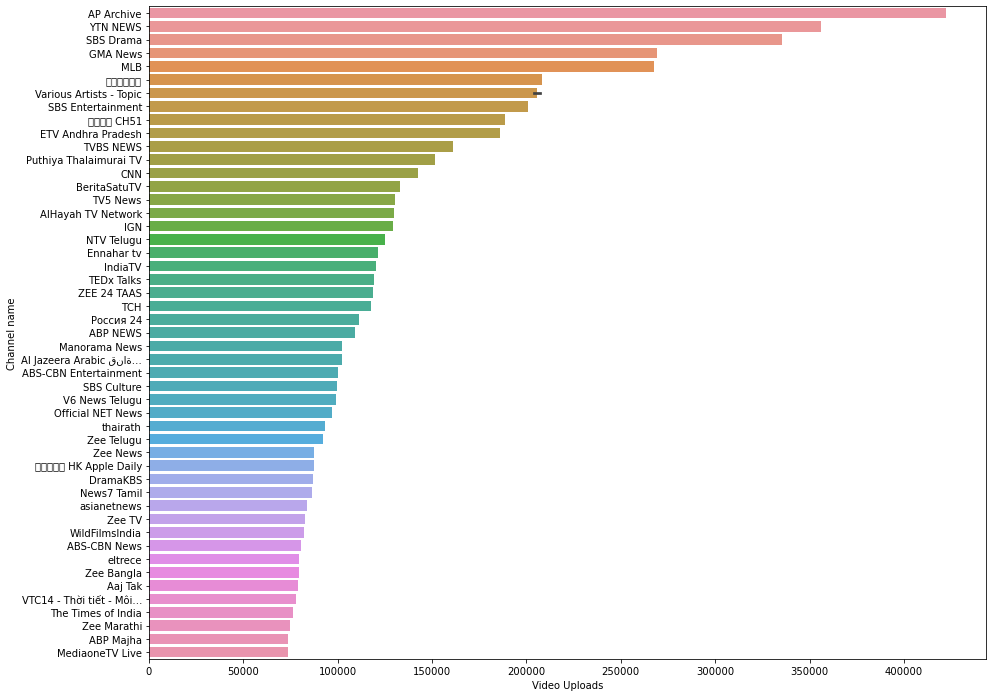

```python
df_views_and_channels_top_50 = data_final[['Channel name','Video Uploads']].sort_values('Video Uploads',
                                                                                        ascending = False)[:50]
fig, ax = plt.subplots(figsize = (15, 12))
sns.barplot(y = 'Channel name', x = 'Video Uploads', data = df_views_and_channels_top_50, orient = 'h',ax = ax)
```

### 8 . Find Grade Distributions

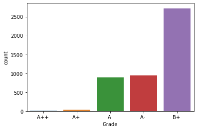

```python
# Countplot
import seaborn as sns
sns.countplot(data_final['Grade'])
```

#### We can see that maximum channels are having B+ grade .

### 9 . Find Relationship

#### Now, let's see the relationship between the rank and grade of a channel.

```python
data_rank_grade = data_final[['Rank', 'Grade']]
```

```python
# Let's observe the rank distribution of the data_rank_grade dataframe.
# Let's convert the Rank series of 'data_rank_grade' to int so analysis becomes easier.
```

```python
l = list(data_rank_grade['Rank'])
rank_list = [i.split(',')[0] + i.split(',')[1] if i[1] == ',' else i[:-2] for i in l]
final_list = [i[:-2] if len(i) == 6 else i for i in rank_list]
int_rank_series = pd.DataFrame(final_list, columns = ['Rank'], dtype = int)
data_rank_grade = data_rank_grade.drop('Rank', axis = 1)
data_rank_grade_new = pd.concat([data_rank_grade, int_rank_series], axis = 1)
data_rank_grade_new.head(20)
```

|  | Grade | Rank |
| --- | --- | --- |
| 0 | A++ | 1.0 |
| 1 | A++ | 2.0 |
| 2 | A++ | 3.0 |
| 3 | A++ | 4.0 |
| 4 | A++ | 5.0 |
| 5 | A++ | 6.0 |
| 6 | A++ | 7.0 |
| 7 | A++ | 8.0 |
| 8 | A++ | 9.0 |
| 9 | A++ | 10.0 |
| 10 | A+ | 11.0 |
| 11 | A+ | 12.0 |
| 12 | A+ | 13.0 |
| 13 | A+ | 14.0 |
| 14 | A+ | 15.0 |
| 15 | A+ | 16.0 |
| 16 | A+ | 17.0 |
| 17 | NaN | 19.0 |
| 18 | A+ | 20.0 |
| 19 | A+ | 21.0 |

#### Here we can see that only top 10 channels are having A++ grade .

#### Let's see the relationship between the Rank & Grade columns via a boxplot.

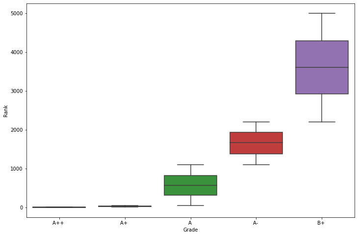

```python
fig, ax = plt.subplots(figsize = (12, 8))
sns.boxplot(x = 'Grade', y = 'Rank', data = data_rank_grade_new, ax = ax)
```

##### We can clearly see that a very good dividing line is there between various grades of channels based on their ranks, thus the ranks of channels are very good indicators of grade of a channel.

#### Observations :

[output not shown]

#### Let's see the relationship between the Subscribers & Grade columns via a boxplot.

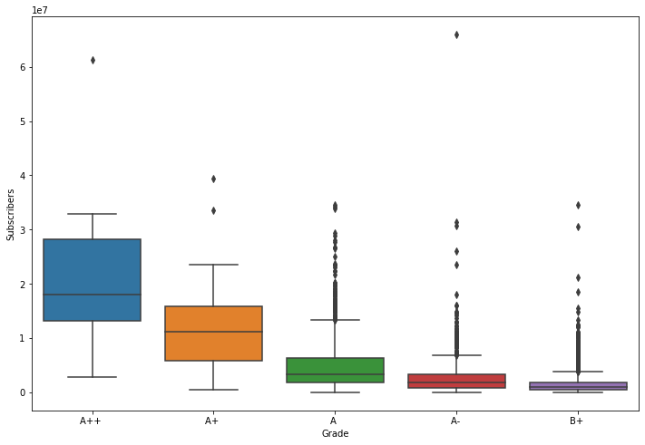

```python
fig, ax = plt.subplots(figsize = (12, 8))
sns.boxplot(x = 'Grade', y = 'Subscribers', data = data_final)
```

#### Observations :

```
 -> Lot of overlaps between the boxes of the grades.
 -> Lot of Outliers.
 -> Subscribers is not a good indicator of the Channel's Grade.
```

### 10 . Do Comparisions

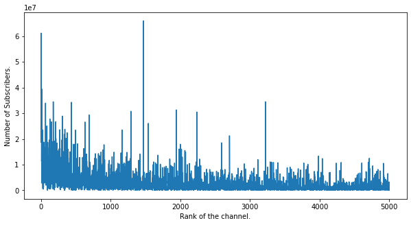

```python
# Comparison between Subscribers and Rank of the channels.

data_final['Subscribers'].plot(figsize = (10,5))
plt.xlabel('Rank of the channel.')
plt.ylabel('Number of Subscribers.')
```

#### Observations :

```
 -> Channels are not ranked according to the number of subscribers.
```

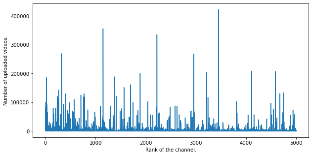

```python
# Comparison between Rank and Video Uploads.

data_final['Video Uploads'].plot(figsize = (10,5))
plt.xlabel('Rank of the channel.')
plt.ylabel('Number of uploaded videos.')
```

#### Observations:

```
 -> Rank does not depend upon number of videos uploaded.
```

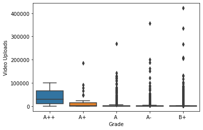

```python
# Comparison between Grade and Video Uploads.
sns.boxplot(x = 'Grade', y = 'Video Uploads', data = data_final )
```

#### Obervations:

```
 -> Grade of the channel does not depends upon the number of videos uploaded.
```

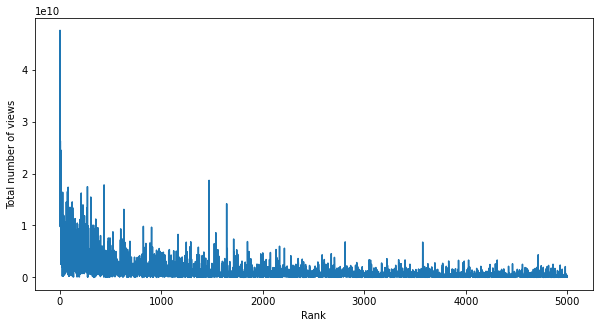

```python
# Comparison between Rank and Video Views.
data_final['Video views'].plot(figsize=(10,5))
plt.xlabel('Rank')
plt.ylabel('Total number of views')
```

#### Observations:

```
 -> Rank of the channel depends upon the number of views.
 -> There are few exceptions.
```

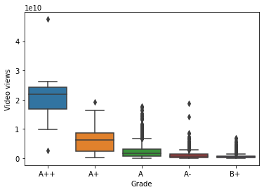

```python
# Comparison between Grade and Video Views.
sns.boxplot(x = 'Grade', y = 'Video views', data = data_final)
```

#### Observations:

```
 -> Grades positively depends upen the number of views.
```

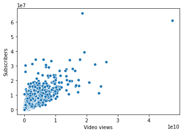

```python
# Comparison among all the continous variables i.e. Video Views and Subscribers.
sns.scatterplot(x = 'Video views', y = 'Subscribers', data = data_final)
```

#### Obervations:

```
 -> More Video Views means more number of Subscribers.
 -> Relationship is Linear.
```

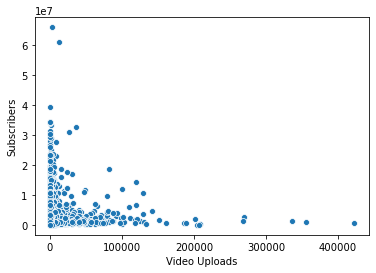

```python
# Comparison between Subscribers and Video Uploads.
sns.scatterplot(x = 'Video Uploads', y = 'Subscribers', data = data_final)
```

#### Obervations:

```
 -> No Strong Relationship.
 -> Large Variance.
```

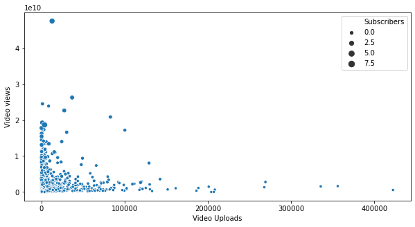

```python
# Comparison between Video Views and Video Uploads.
fig, ax = plt.subplots(figsize = (10, 5))
sns.scatterplot(x = 'Video Uploads', y = 'Video views', size = 'Subscribers', data = data_final, ax = ax)
```

#### Obervations:

```
 -> Not Strongly Linear.
```

```python
# Let's create a new variable "Views per Upload" for a better analysis.
data_final['Views per Upload'] = data_final['Video views'] / data_final['Video Uploads']
data_final['Views per Upload'].head(10)
```

```
0    2.521815e+05
1    3.755536e+06
2    2.625551e+07
3    8.299216e+05
4    7.148130e+05
5    5.494857e+05
6    2.811615e+06
7    1.717736e+05
8    2.150710e+07
9    3.473977e+04
Name: Views per Upload, dtype: float64
```

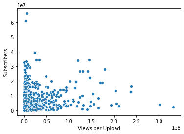

```python
# Comparison between Subscribers and Views per Upload.
sns.scatterplot(x = 'Views per Upload', y = 'Subscribers', data = data_final)
```

#### Obervations:

[output not shown]

### 11 . Find Correlations

```python
# Mathematical Relationship between Video Views and Subscribers.
corr_coef = np.corrcoef(x = data_final['Video views'], y = data_final['Subscribers'])
corr_coef
```

```
array([[1.        , 0.79124115],
       [0.79124115, 1.        ]])
```

#### Observation:

```
 -> Positive Correlation.
```

```python
# Mathematical Relation between Subscribers and Video Uploads.
corr_coef = np.corrcoef(x = data_final['Video Uploads'], y = data_final['Subscribers'])
corr_coef
```

```
array([[1.        , 0.01136205],
       [0.01136205, 1.        ]])
```

#### Observations:

```
 -> Poor Correlation
```

```python
# Mathematical Relation between Views per Upload and Subscribers .
corr_coef = np.corrcoef(x = data_final['Views per Upload'], y = data_final['Subscribers'])
corr_coef
```

```
array([[1.        , 0.28938596],
       [0.28938596, 1.        ]])
```

#### Obervations:

```
 -> Views per Upload have better correlation with Subscribers, and can be used to predict the subscribers.
```

### 12 . Conclusion

#### Hence my final observations are :

```
1) Rank of the channels are good indicator of the grades of the channels.
2) Grades of the channels are not depended upon the subscribers of the channels.
3) Rank can be predicted by the number of views of the videos.
4) Grades are positively depended upon the number of views of the videos.
5) Number of Subscribers are positively depended upon the number of Video Views.
6) No strong relationship between the number of Subscribers and number of Video Uploads.
7) Number of subscribers are positively depended upon the Views Per Upload.
```

### < kp@2020 >